# Skull Stripping and Registration of Head CT Data

# Goal

In this tutorial, we will discuss skull-stripping (or brain-extracting) X-ray computed tomography (CT) scans. We will use data from TCIA (http://www.cancerimagingarchive.net/). The entire pipeline goes from raw DICOM data, converts it to NIfTI images, performs brain extraction, and then spatially normalizes the brain to a template using non-linear registration. All of the packages are open source and are available through [CRAN](https://cran.r-project.org/) or [Neuroconductor (https://neuroconductor.org/)](https://neuroconductor.org/) for the R programming language. We extract data from TCIA from the [`TCIApathfinder`](https://CRAN.R-project.org/package=TCIApathfinder) R package.

## Installing Packages

In order to run all the code in this tutorial, these packages need to be installed. The following code should install all the packages.

```r
install.packages(c("TCIApathfinder", "dplyr"))
source("https://neuroconductor.org/neurocLite.R")
neuro_install(c("dcm2niir", "ichseg", "fslr", "extrantsr"))
```

## Using TCIApathfinder

```r
library(TCIApathfinder)
library(dplyr)
```

```r
series_instance_uid = "1.3.6.1.4.1.14519.5.2.1.2857.3707.893926543922125108620513439908"
download_unzip_series = function(series_instance_uid,
                                 verbose = TRUE) {
  tdir = tempfile()
  dir.create(tdir, recursive = TRUE)
  tfile = tempfile(fileext = ".zip")
  tfile = basename(tfile)
  if (verbose) {
    message("Downloading Series")
  }
  res = save_image_series(
    series_instance_uid = series_instance_uid,
    out_dir = tdir,
    out_file_name = tfile)
  if (verbose) {
    message("Unzipping Series")
  }
  stopifnot(file.exists(res$out_file))
  tdir = tempfile()
  dir.create(tdir, recursive = TRUE)
  res = unzip(zipfile = res$out_file, exdir = tdir)
  L = list(files = res,
           dirs = unique(dirname(normalizePath(res))))
  return(L)
}
# Download and unzip the image series

file_list = download_unzip_series(
  series_instance_uid = series_instance_uid)
```

```
Downloading Series
```

```
Unzipping Series
```

Here we extracted a single series of a CT brain scan. The data are in DICOM format.

## Converting DICOM to NIfTI

We will use [`dcm2niix`](https://github.com/rordenlab/dcm2niix) to convert the data from DICOM to NIfTI. The function `dcm2niix` is wrapped in the `dcm2niir` R package (Muschelli 2018). We will use `dcm2niir::dcm2nii` to convert the file. We use `check_dcm2nii` to grab the relevant output files:

```r
library(dcm2niir)
dcm_result = dcm2nii(file_list$dirs)
```

```
#Copying Files
```

```
# Converting to nii
```

```
'/Library/Frameworks/R.framework/Versions/3.6/Resources/library/dcm2niir/dcm2niix' -9 -z y -f %p_%t_%s '/var/folders/1s/wrtqcpxn685_zk570bnx9_rr0000gr/T//Rtmp5zn4fm/file90e86ff1b312'
```

```r
dcm_result$nii_after
```

```
[1] "/var/folders/1s/wrtqcpxn685_zk570bnx9_rr0000gr/T//Rtmp5zn4fm/file90e86ff1b312/HEAD_STD_20010124161800_2_Tilt_1.nii.gz"
[2] "/var/folders/1s/wrtqcpxn685_zk570bnx9_rr0000gr/T//Rtmp5zn4fm/file90e86ff1b312/HEAD_STD_20010124161800_2.nii.gz"
```

```r
result = check_dcm2nii(dcm_result)
result
```

```
[1] "/var/folders/1s/wrtqcpxn685_zk570bnx9_rr0000gr/T//Rtmp5zn4fm/file90e86ff1b312/HEAD_STD_20010124161800_2_Tilt_1.nii.gz"
attr(,"json_file")
[1] "/var/folders/1s/wrtqcpxn685_zk570bnx9_rr0000gr/T//Rtmp5zn4fm/file90e86ff1b312/HEAD_STD_20010124161800_2.json"
```

Here we see the output is a single NIfTI file. If there is any gantry tilt or variable slice thickness, `dcm2niix` has accounted for this.

Next we read the data into `R` into a `nifti` object:

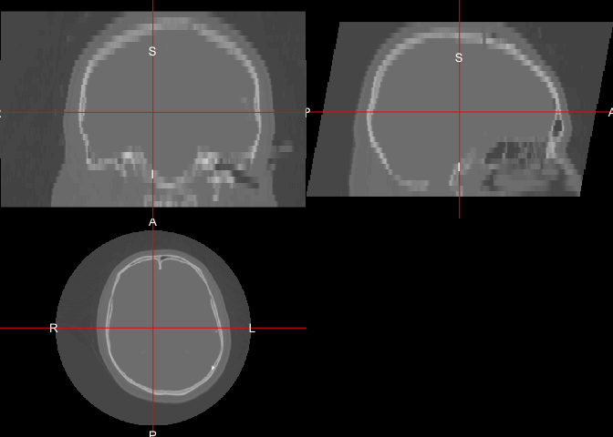

```r
library(neurobase)
img = readnii(result)
ortho2(img)
```

```r
range(img)
```

```
[1] -3024  3071
```

Here we will use `neurobase::rescale_img` to make sure the minimum is $-1024$ and the maximum is $3071$. The minimum can be lower for areas outside the field of view (FOV). Here we plot the image and the Winsorized version to see the brain tissue:

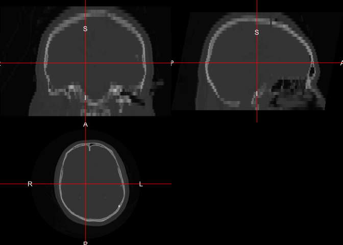

```r
img = rescale_img(img, min.val = -1024, max.val = 3071)
ortho2(img)
```

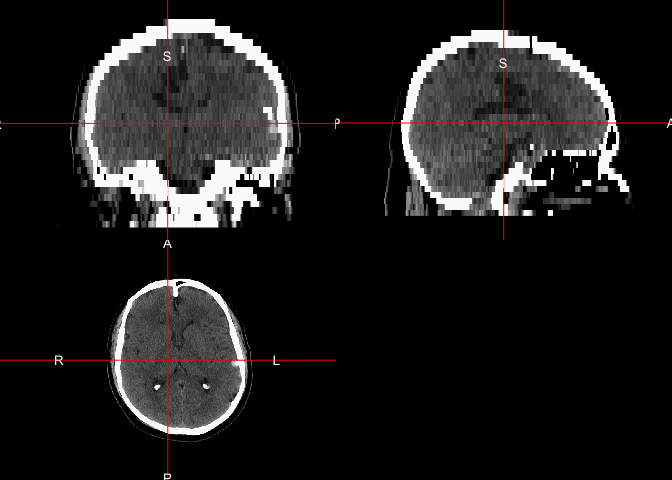

```r
ortho2(img, window = c(0, 100))
```

We see the image has high resolution within the axial plane, but not as high resolution in the sagittal plane. We see high values in the skull and other dense areas and lower values within the brain and the darkest values outside of the head.

## Skull Strip

We can skull strip the image using `CT_Skull_Strip` or `CT_Skull_Stripper` from the `ichseg` R package. The `CT_Skull_Stripper` has a simple switch to use `CT_Skull_Strip` or `CT_Skull_Strip_robust` (Muschelli 2019b).

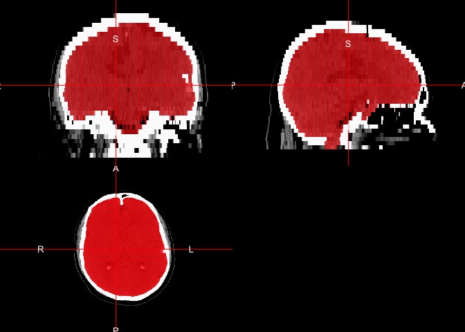

```r
library(ichseg)
ss = CT_Skull_Strip(img, verbose = FALSE)
ortho2(img, ss > 0,
       window = c(0, 100),
       col.y = scales::alpha("red", 0.5))
```

The `CT_Skull_Strip_robust` function does 2 neck removals using `remove_neck` from `extrantsr` and then find the center of gravity (COG) twice to make sure the segmentation focuses on the head, which uses some FSL (Jenkinson et al. 2012) functions in the `fslr` package (Muschelli et al. 2015). In some instances, the whole neck is included in the scan, such as some of the head-neck studies in TCIA.

## Registration

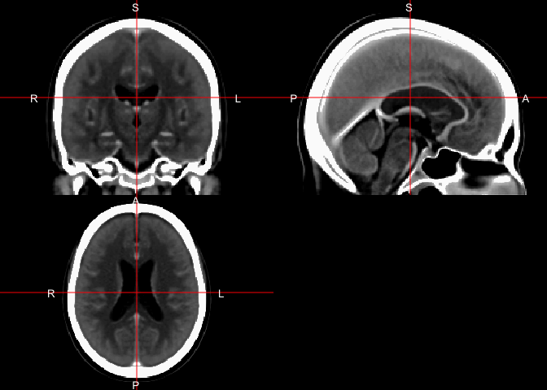

```r
template_image = ichseg::ct_template(type = "image")
ortho2(template_image, window = c(0, 100))
```

```r
reg = extrantsr::registration(
  img, template.file = template_image,
  typeofTransform = "SyN",
  interpolator = "Linear")
```

```
# Running Registration of file to template
```

```
# Applying Registration output is
```

```
$fwdtransforms
[1] "/var/folders/1s/wrtqcpxn685_zk570bnx9_rr0000gr/T//Rtmp5zn4fm/file90e81554bff81Warp.nii.gz"
[2] "/var/folders/1s/wrtqcpxn685_zk570bnx9_rr0000gr/T//Rtmp5zn4fm/file90e81554bff80GenericAffine.mat"

$invtransforms
[1] "/var/folders/1s/wrtqcpxn685_zk570bnx9_rr0000gr/T//Rtmp5zn4fm/file90e81554bff80GenericAffine.mat"
[2] "/var/folders/1s/wrtqcpxn685_zk570bnx9_rr0000gr/T//Rtmp5zn4fm/file90e81554bff81InverseWarp.nii.gz"

$prev_transforms
character(0)
```

```
# Applying Transformations to file
```

[output not shown]

```
# Writing out file
```

```
[1] "/var/folders/1s/wrtqcpxn685_zk570bnx9_rr0000gr/T//Rtmp5zn4fm/file90e86c15f438.nii.gz"
```

```
# Reading data back into R
```

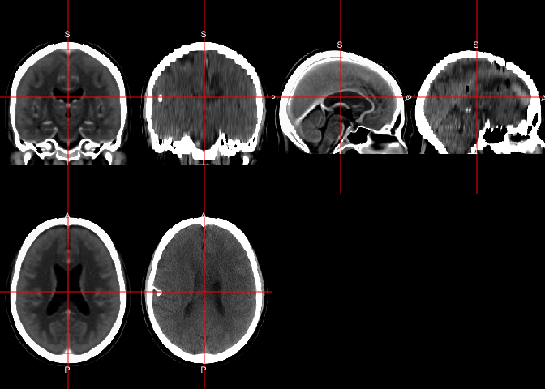

```r
wimg = window_img(reg$outfile, window = c(0, 100))
double_ortho(template_image, wimg, window = c(0, 100))
```

We see relatively good alignment between the template image (left) and the registered image (right)

Here we will use the skull-stripped template and perform the same registration with the skull-stripped image.

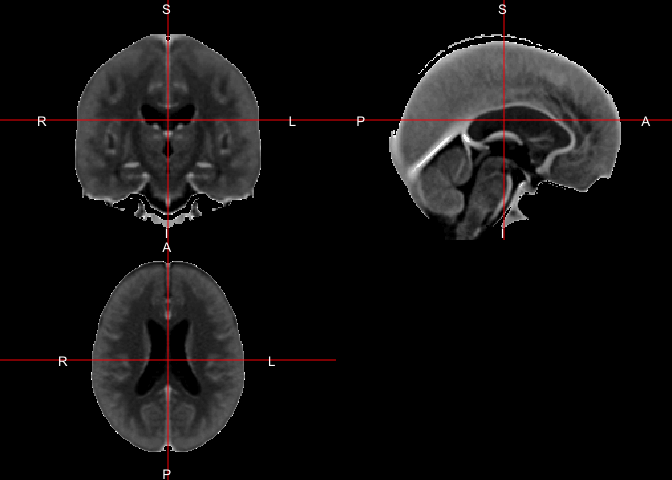

```r
template_brain = ichseg::ct_template(type = "brain")
ortho2(template_brain, window = c(0, 100))
```

```r
brain_reg = extrantsr::registration(
  ss, template.file = template_brain,
  typeofTransform = "SyN",
  interpolator = "Linear")
```

```
# Running Registration of file to template
```

```
# Applying Registration output is
```

```
$fwdtransforms
[1] "/var/folders/1s/wrtqcpxn685_zk570bnx9_rr0000gr/T//Rtmp5zn4fm/file90e87a2ad82c1Warp.nii.gz"
[2] "/var/folders/1s/wrtqcpxn685_zk570bnx9_rr0000gr/T//Rtmp5zn4fm/file90e87a2ad82c0GenericAffine.mat"

$invtransforms
[1] "/var/folders/1s/wrtqcpxn685_zk570bnx9_rr0000gr/T//Rtmp5zn4fm/file90e87a2ad82c0GenericAffine.mat"
[2] "/var/folders/1s/wrtqcpxn685_zk570bnx9_rr0000gr/T//Rtmp5zn4fm/file90e87a2ad82c1InverseWarp.nii.gz"

$prev_transforms
character(0)
```

```
# Applying Transformations to file
```

[output not shown]

```
# Writing out file
```

```
[1] "/var/folders/1s/wrtqcpxn685_zk570bnx9_rr0000gr/T//Rtmp5zn4fm/file90e8141912f2.nii.gz"
```

```
# Reading data back into R
```

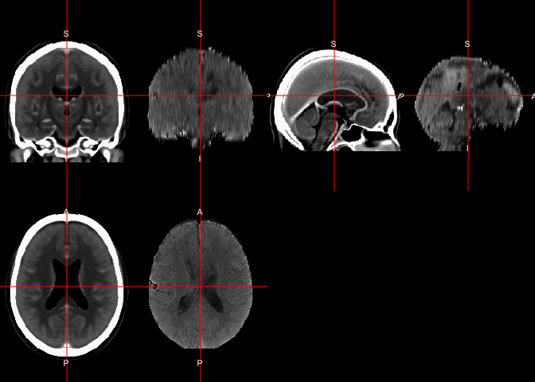

```r
wbrain = window_img(brain_reg$outfile, window = c(0, 100))
double_ortho(template_image, wbrain, window = c(0, 100))
```

We see again good alignment, but we see that there are some stark differences in these registrations when we compare them:

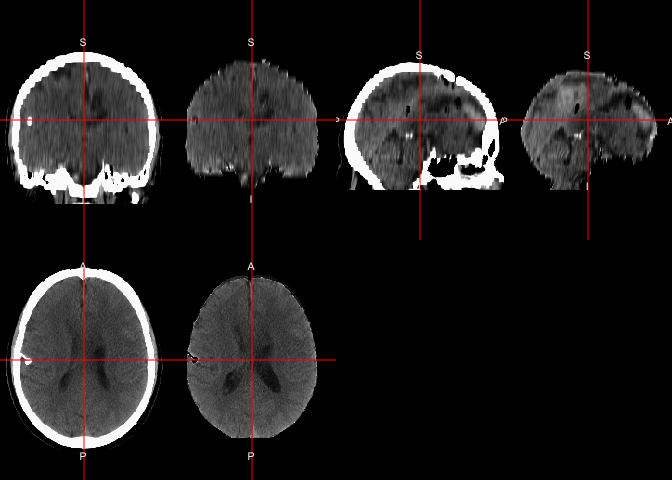

```r
double_ortho(wimg, wbrain)
```

Avants, Brian B. 2019. *ANTsR: ANTs in R: Quantification Tools for Biomedical Images*.

Jenkinson, Mark, Christian F Beckmann, Timothy EJ Behrens, Mark W Woolrich, and Stephen M Smith. 2012. “FSL.” *NeuroImage* 62 (2): 782–90.

Muschelli, John. 2018. *dcm2niir: Conversion of DICOM to NIfTI Imaging Files Through R*. https://www.nitrc.org/plugins/mwiki/index.php/dcm2nii:MainPage.

———. 2019a. *extrantsr: Extra Functions to Build on the ANTsR Package*.

———. 2019b. *ichseg: Intracerebral Hemorrhage Segmentation of X-Ray Computed Tomography (CT) Images*.

Muschelli, John, Elizabeth Sweeney, Martin Lindquist, and Ciprian Crainiceanu. 2015. “fslr: Connecting the FSL Software with R.” *The R Journal* 7 (1): 163–75.

Russell, Pamela, Kelly Fountain, Dulcy Wolverton, and Debashis Ghosh. 2018. “TCIApathfinder: An R Client for the Cancer Imaging Archive REST API.” *Cancer Research* 78 (15): 4424–6.